# Homework Assignment 6

Arman Aghamyan

14/04/2019

You are required to submit both Markdown and HTML files with your answers and code in it. Do not remove problems from your Markdown file. Please write your name at the beginning of your file into the YAML-header inside of author.

Data set relevant for this assignment can be found on Moodle. The description of the variables is given in a separate file.

Good luck!

```
                                               Task 1   (4 pt.)
a. Clean and describe the final data. Which of variables can be useful for survival analysis? Why? Which of them can be an event indicator?
b. What is the difference between interval censored and point censored data?
c. What are the mail causes of censored data (right-censored)? Why  cannot we ignore censoring, bring and example?
```

```r
library(dplyr)
library(tidyr)
set.seed(1)
surv<-read.csv("survdata.csv")
str(surv)
```

```
## 'data.frame':    3400 obs. of  15 variables:
##  $ X        : int  1 2 3 4 5 6 7 8 9 10 ...
##  $ chldage  : num  12 12 3 2 4 12 7 3 7 12 ...
##  $ hospital : int  0 0 0 0 0 0 0 0 0 NA ...
##  $ mthage   : int  22 20 24 22 21 20 24 24 26 21 ...
##  $ alcohol  : int  0 1 3 2 1 0 0 3 2 1 ...
##  $ smoke    : int  0 0 0 2 2 0 0 0 2 0 ...
##  $ region   : int  1 1 1 1 1 1 1 1 1 1 ...
##  $ poverty  : int  1 1 1 NA 1 1 1 1 1 1 ...
##  $ bweight  : int  1 0 0 0 1 0 0 0 0 0 ...
##  $ race     : int  1 1 1 1 1 1 1 1 1 1 ...
##  $ education: int  10 12 12 9 12 12 12 14 12 12 ...
##  $ nsibs    : int  1 1 2 0 0 0 1 0 0 0 ...
##  $ wmonth   : int  1 2 1 0 0 0 0 4 1 3 ...
##  $ sfmonth  : int  1 2 0 0 0 0 0 2 1 2 ...
##  $ agepn    : int  1 12 3 2 4 12 7 3 6 12 ...
```

```r
surv<-na.omit(surv)
any(duplicated(surv$X))
```

```
## [1] FALSE
```

```r
surv<-select(surv,-X)
surv$alcohol<-ifelse(surv$alcohol>0,1,0)
surv$smoke<-ifelse(surv$smoke>0,1,0)
surv$hospital<-ifelse(surv$hospital==1,1,0)
surv$alcohol<-as.factor(surv$alcohol)
surv$smoke<-as.factor(surv$smoke)
surv$region<-as.factor(surv$region)
surv$poverty<-as.factor(surv$poverty)
surv$race<-as.factor(surv$race)
surv$bweight<-as.factor(surv$bweight)
glimpse(surv)
```

```
## Observations: 3,385
## Variables: 14
## $ chldage   <dbl> 12.0, 12.0, 3.0, 4.0, 12.0, 7.0, 3.0, 7.0, 12.0, 12....
## $ hospital  <dbl> 0, 0, 0, 0, 0, 0, 0, 0, 0, 0, 0, 0, 0, 0, 0, 0, 0, 0...
## $ mthage    <int> 22, 20, 24, 21, 20, 24, 24, 26, 24, 27, 20, 25, 21, ...
## $ alcohol   <fct> 0, 1, 1, 1, 0, 0, 1, 1, 0, 0, 0, 1, 1, 0, 1, 1, 1, 0...
## $ smoke     <fct> 0, 0, 0, 1, 0, 0, 0, 1, 0, 0, 0, 0, 1, 1, 0, 0, 1, 1...
## $ region    <fct> 1, 1, 1, 1, 1, 1, 1, 1, 1, 1, 1, 1, 1, 1, 1, 1, 1, 1...
## $ poverty   <fct> 1, 1, 1, 1, 1, 1, 1, 1, 1, 1, 1, 1, 1, 1, 1, 1, 1, 1...
## $ bweight   <fct> 1, 0, 0, 1, 0, 0, 0, 0, 0, 0, 1, 0, 0, 0, 0, 0, 1, 0...
## $ race      <fct> 1, 1, 1, 1, 1, 1, 1, 1, 1, 1, 1, 1, 1, 1, 1, 1, 1, 1...
## $ education <int> 10, 12, 12, 12, 12, 12, 14, 12, 16, 16, 12, 12, 9, 1...
## $ nsibs     <int> 1, 1, 2, 0, 0, 1, 0, 0, 0, 1, 0, 0, 0, 0, 1, 0, 0, 0...
## $ wmonth    <int> 1, 2, 1, 0, 0, 0, 4, 1, 0, 0, 0, 4, 1, 9, 10, 9, 4, ...
## $ sfmonth   <int> 1, 2, 0, 0, 0, 0, 2, 1, 0, 0, 0, 2, 1, 2, 3, 9, 3, 0...
## $ agepn     <int> 1, 12, 3, 4, 12, 7, 3, 6, 12, 12, 3, 4, 4, 10, 3, 7,...
```

B)Interval censored meanes that we know in which interval we have censored data,but exactly when we can not say. Point censored data exactly mention when we have censored our data,we can say when we lost our datapoint.

C)For example, let the time-to-event be a person’s age at onset of cancer. If you stop following someone after age 65, you may know that the person did NOT have cancer at age 65, but you do not have any information after that age.

You know that their age of getting cancer is greater than 65. But you do not know if they will never get cancer or if they’ll get it at age 66, only that they have a “survival” time greater than 65 years. They are censored because we did not gather information on that subject after age 65.

So one cause of censoring is merely that we can’t follow people forever. At some point you have to end your study, and not all people will have experienced the event.

But another common cause is that people are lost to follow-up during a study. This is called random censoring. It occurs when follow-up ends for reasons that are not under control of the investigator.

In survival analysis, censored observations contribute to the total number at risk up to the time that they ceased to be followed. One advantage here is that the length of time that an individual is followed does not have to be equal for everyone. All observations could have different amounts of follow-up time, and the analysis can take that into account.

```
                                               Task 2   (6 pt.)
  Create survival object to solve the task, use the KM method.

  a. What is the probability of surviving to a certain point in time (baseline model without predictors)? Use n.risk and n.event of summary function to comment on this task.
  b. Why is the KM model called non-parametric?
  c. Plot the survival probability and cumulative hazard functions. Comment on it.
  d. Add independent variable/s (with more than 2 categories) to your model to create survival curves for different groups.
  e. Find the variable with significant differences in survival probabilities. Show the survival plot and add a risk table to the graph. Comment on it.
```

B)Non-parametric (or distribution-free) inferential statistical methods are mathematical procedures for statistical hypothesis testing which, unlike parametric statistics, make no assumptions about the probability distributions of the variables being assessed.One of them is Kaplan-Meier.

C)From surviving plot we see the difference very small aproximately 2,5%,hazard is the probability of get in to the hospital(not surviving) and in this plot it is more visually seen how much by each month the probability to get hospitalizied (not to survive) is increaseing.

E)As we see children with birthweight < 5.5 aproximately by 80% are risky to get hospiatlized than children with high birth wieght.

```r
library(survival)
library(survminer)
# D)
set.seed(1)
surv_object<-Surv(time = surv$chldage,event = surv$hospital)
km_1<-survfit(surv_object~1,data=surv)
summary(km_1)
```

```
## Call: survfit(formula = surv_object ~ 1, data = surv)
##
##  time n.risk n.event survival std.err lower 95% CI upper 95% CI
##     1   3302      21    0.994 0.00138        0.991        0.996
##     2   3200      14    0.989 0.00180        0.986        0.993
##     3   3105      12    0.985 0.00210        0.981        0.990
##     4   3010       4    0.984 0.00220        0.980        0.988
##     5   2916       5    0.982 0.00232        0.978        0.987
##     6   2805       5    0.981 0.00245        0.976        0.986
##     7   2706       1    0.980 0.00247        0.976        0.985
##     8   2609       2    0.980 0.00253        0.975        0.985
##     9   2513       4    0.978 0.00264        0.973        0.983
##    10   2426       2    0.977 0.00270        0.972        0.983
##    11   2348       2    0.976 0.00276        0.971        0.982
```

```r
table(surv$chldage,surv$hospital)
```

```
##
##          0    1
##   0.5   83    0
##   1     81   21
##   2     81   14
##   3     83   12
##   4     90    4
##   5    106    5
##   6     94    5
##   7     96    1
##   8     94    2
##   9     83    4
##   10    76    2
##   11    69    2
##   12  2277    0
```

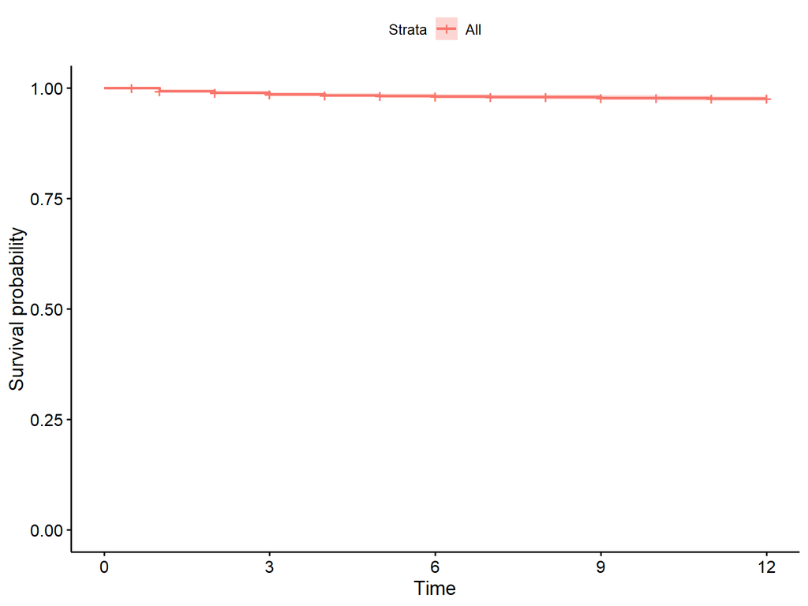

```r
ggsurvplot(km_1,data=surv) # survive
```

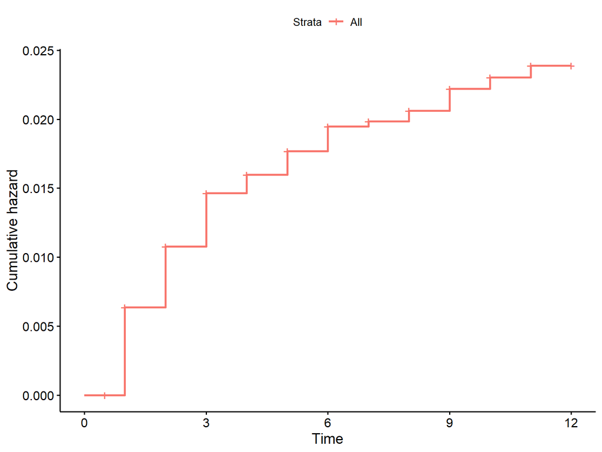

```r
ggsurvplot(km_1,fun="cumhaz",conf.int = F) #hazard
```

```r
km_ra<-survfit(surv_object~race+alcohol,data=surv)
summary(km_ra)
```

```
## Call: survfit(formula = surv_object ~ race + alcohol, data = surv)
##
##                 race=1, alcohol=0
##  time n.risk n.event survival std.err lower 95% CI upper 95% CI
##     1   1040      10    0.990 0.00303        0.984        0.996
##     2   1007       5    0.985 0.00373        0.978        0.993
##     3    973       5    0.980 0.00434        0.972        0.989
##     4    940       2    0.978 0.00457        0.969        0.987
##     5    911       2    0.976 0.00481        0.967        0.986
##    11    728       2    0.973 0.00516        0.963        0.984
##
##                 race=1, alcohol=1
##  time n.risk n.event survival std.err lower 95% CI upper 95% CI
##     1    773       5    0.994 0.00288        0.988        0.999
##     2    748       3    0.990 0.00368        0.982        0.997
##     3    720       2    0.987 0.00415        0.979        0.995
##     4    699       1    0.985 0.00438        0.977        0.994
##     5    674       1    0.984 0.00461        0.975        0.993
##     7    624       1    0.982 0.00486        0.973        0.992
##     8    601       1    0.981 0.00512        0.971        0.991
##     9    578       1    0.979 0.00539        0.969        0.990
##
##                 race=2, alcohol=0
##  time n.risk n.event survival std.err lower 95% CI upper 95% CI
##     1    678       2    0.997 0.00208        0.993        1.000
##     2    659       1    0.996 0.00257        0.991        1.000
##     3    643       2    0.992 0.00337        0.986        0.999
##     5    606       2    0.989 0.00408        0.981        0.997
##     6    587       2    0.986 0.00471        0.977        0.995
##    10    520       1    0.984 0.00507        0.974        0.994
##
##                 race=2, alcohol=1
##  time n.risk n.event survival std.err lower 95% CI upper 95% CI
##     2    238       3    0.987 0.00723        0.973        1.000
##     3    230       1    0.983 0.00838        0.967        1.000
##     6    210       1    0.978 0.00956        0.960        0.997
##     9    192       3    0.963 0.01285        0.938        0.989
##
##                 race=3, alcohol=0
##  time n.risk n.event survival std.err lower 95% CI upper 95% CI
##     1    415       3    0.993 0.00416        0.985        1.000
##     2    401       2    0.988 0.00541        0.977        0.998
##     3    395       2    0.983 0.00644        0.970        0.996
##     4    379       1    0.980 0.00692        0.967        0.994
##     6    355       1    0.977 0.00744        0.963        0.992
##     8    328       1    0.974 0.00799        0.959        0.990
##    10    299       1    0.971 0.00860        0.955        0.988
##
##                 race=3, alcohol=1
##  time n.risk n.event survival std.err lower 95% CI upper 95% CI
##     1    150       1    0.993 0.00664        0.980            1
##     6    128       1    0.986 0.01016        0.966            1
```

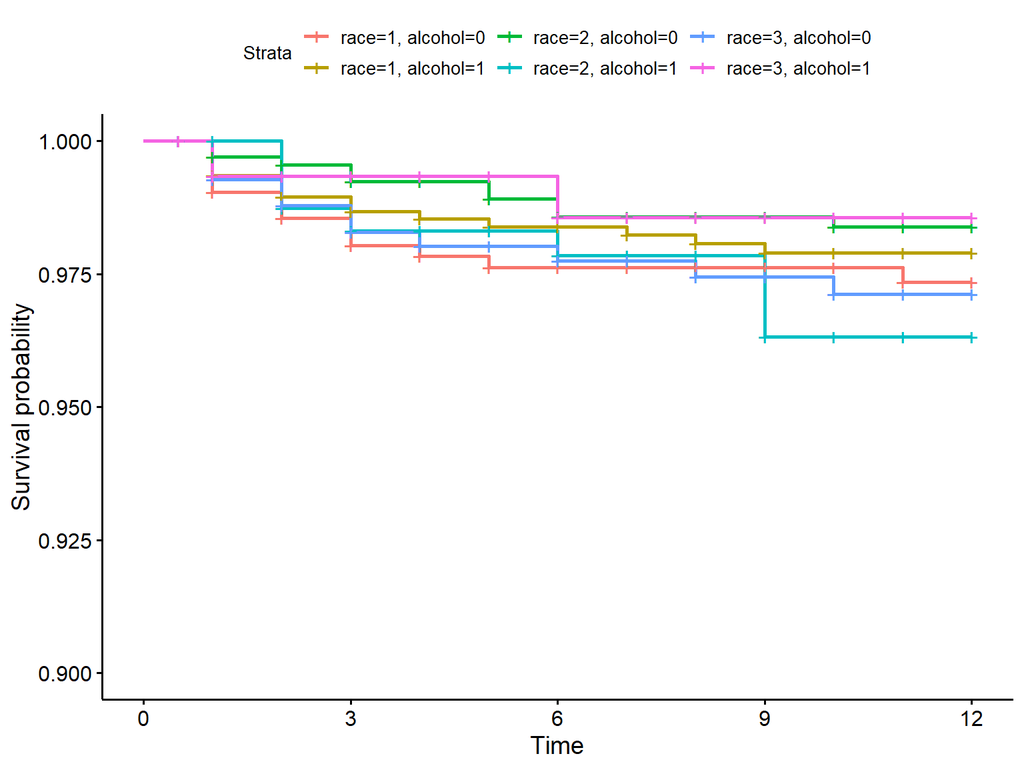

```r
ggsurvplot(km_ra,conf.int = F,ylim=c(0.9,1))
```

```r
survdiff(surv_object~bweight,data=surv)
```

```
## Call:
## survdiff(formula = surv_object ~ bweight, data = surv)
##
##              N Observed Expected (O-E)^2/E (O-E)^2/V
## bweight=0 2160       35     45.8      2.56      7.08
## bweight=1 1225       37     26.2      4.49      7.08
##
##  Chisq= 7.1  on 1 degrees of freedom, p= 0.008
```

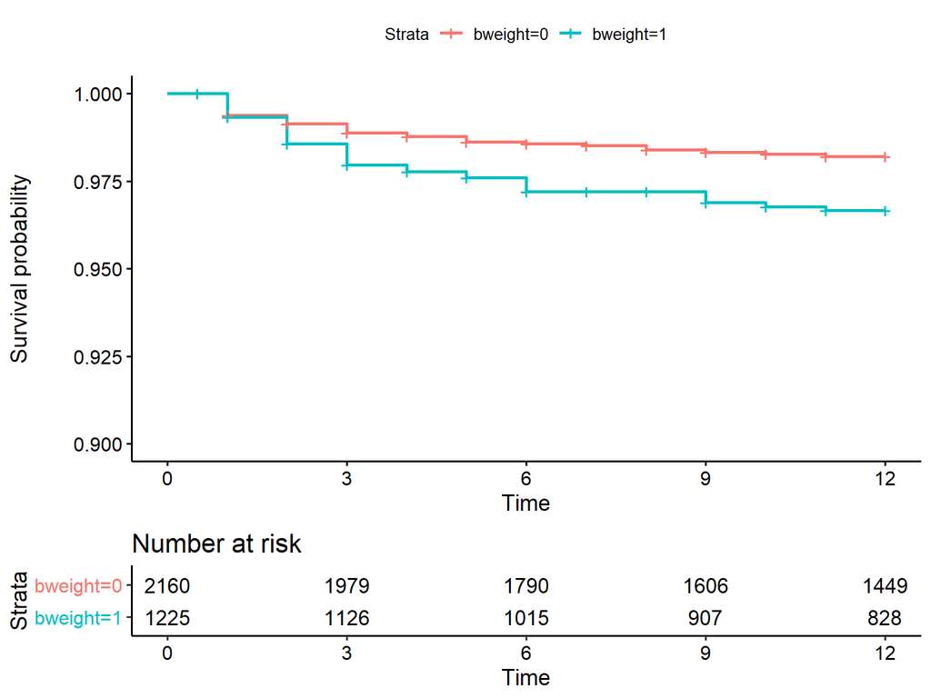

```
                                               Task 3   (4 pt.)
a. Run the ATF model with independent variables (at least one numeric and one categorical). Overall model and coefficients must be significant. Interpret the coefficients.
b. Make predictions based on your model using quantiles. Why do we not use the predict function?
c. Plot probability of a hazard and survival. Comment on it.
```

```r
km_reg<-survfit(surv_object~bweight,data=surv)
ggsurvplot(km_reg,conf.int = F,ylim=c(0.9,1),risk.table = T)
```

A)One unit increase in education year increases survival time by 20%. When mother’s race is 2nd category the survival time is increased by 21%.

B)As we want have predictions in time interval we should use quantile method,as response method brings the mean or median,and it is not effective to have such predictions.It does not give us usefull information.

C)As we see by plot by time increase the probability of survival decrease,but probability of hazard increases.

```r
set.seed(1)
reg_model<-survreg(surv_object~education+race,data=surv,dist = "exponential")
summary(reg_model)
```

```
##
## Call:
## survreg(formula = surv_object ~ education + race, data = surv,
##     dist = "exponential")
##              Value Std. Error    z       p
## (Intercept) 4.0397     0.5900 6.85 7.6e-12
## education   0.1824     0.0524 3.48  0.0005
## race2       0.1915     0.2827 0.68  0.4982
## race3       0.2117     0.3280 0.65  0.5187
##
## Scale fixed at 1
##
## Exponential distribution
## Loglik(model)= -508.1   Loglik(intercept only)= -513.7
##  Chisq= 11.34 on 3 degrees of freedom, p= 0.01
## Number of Newton-Raphson Iterations: 7
## n= 3385
```

```r
exp(coef(reg_model))
```

```
## (Intercept)   education       race2       race3
##   56.811335    1.200143    1.211078    1.235782
```

```r
quant=seq(.1,.9,length=9)
pred<-predict(reg_model,type="quantile",p=quant)
head(pred,n=10)
```

```
##            [,1]      [,2]     [,3]     [,4]     [,5]     [,6]      [,7]
##  [1,]  37.10580  78.58656 125.6136 179.9023 244.1122 322.6987  424.0144
##  [2,]  53.44507 113.19157 180.9266 259.1209 351.6051 464.7967  610.7260
##  [3,]  53.44507 113.19157 180.9266 259.1209 351.6051 464.7967  610.7260
##  [4,]  53.44507 113.19157 180.9266 259.1209 351.6051 464.7967  610.7260
##  [5,]  53.44507 113.19157 180.9266 259.1209 351.6051 464.7967  610.7260
##  [6,]  53.44507 113.19157 180.9266 259.1209 351.6051 464.7967  610.7260
##  [7,]  76.97921 163.03464 260.5962 373.2228 506.4318 669.4665  879.6547
##  [8,]  53.44507 113.19157 180.9266 259.1209 351.6051 464.7967  610.7260
##  [9,] 110.87643 234.82573 375.3479 537.5688 729.4353 964.2611 1267.0041
## [10,] 110.87643 234.82573 375.3479 537.5688 729.4353 964.2611 1267.0041
##            [,8]      [,9]
##  [1,]  566.8109  810.9231
##  [2,]  816.4019 1168.0070
##  [3,]  816.4019 1168.0070
##  [4,]  816.4019 1168.0070
##  [5,]  816.4019 1168.0070
##  [6,]  816.4019 1168.0070
##  [7,] 1175.8983 1682.3302
##  [8,]  816.4019 1168.0070
##  [9,] 1693.6964 2423.1318
## [10,] 1693.6964 2423.1318
```

```r
time<-1:12
pred_p<-pexp(time,rate=1/pred[1])
pred_p[1:10]
```

```
##  [1] 0.02659005 0.05247307 0.07766786 0.10219272 0.12606546 0.14930343
##  [7] 0.17192349 0.19394209 0.21537521 0.23623843
```

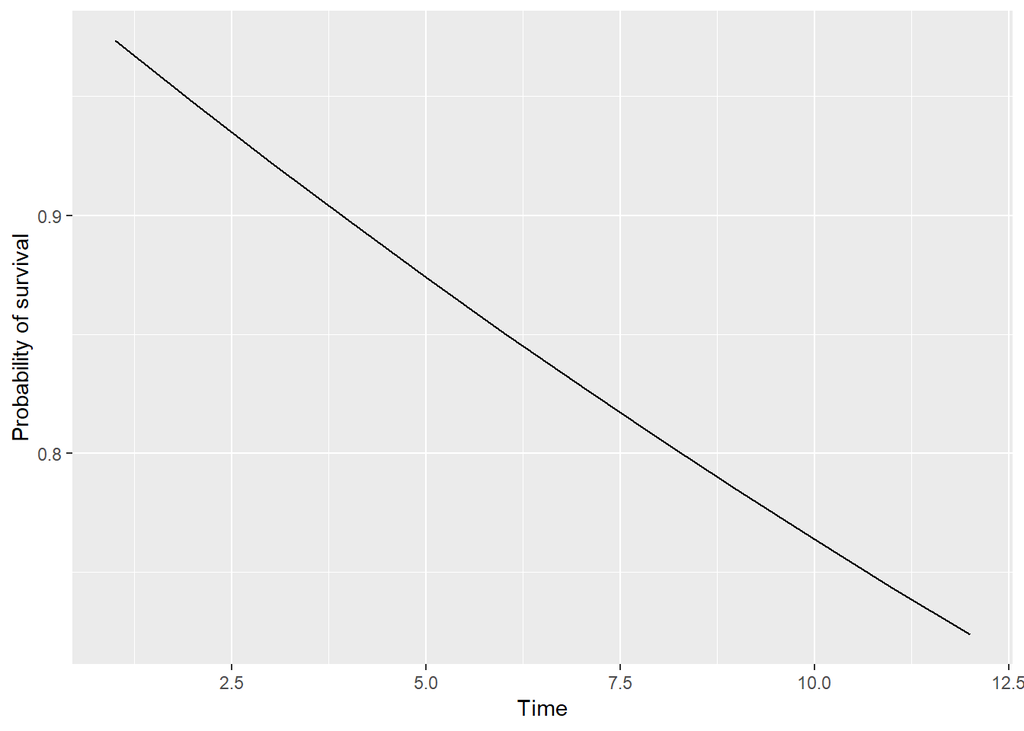

```r
pred_p_surv=1-pred_p
ggplot()+geom_line(aes(x=time,y=pred_p_surv))+labs(x="Time",y="Probability of survival")
```

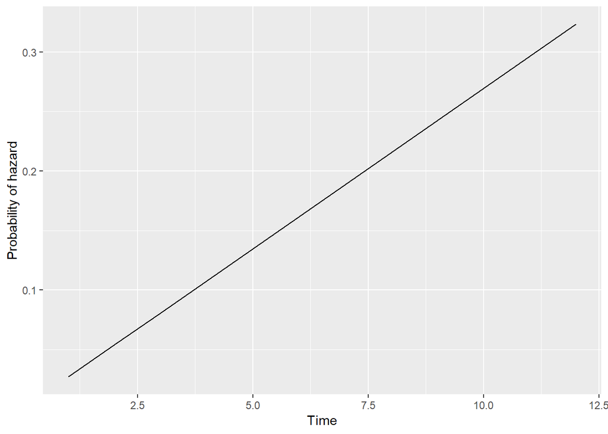

```
                                               Task 4   (6 pt.)

a. Which are the key assumptions of the Cox model?
b. Run the Cox proportional hazard model with significant coefficients. What does Rsquare show?
c. Interpret the coefficients of your model. What does HR indicate?
d. Check the proportional hazard assumption. Comment on it.
e. Make predictions with cox model using plots.
```

```r
pred_p_hazard=-log(pred_p_surv)
ggplot()+geom_line(aes(x=time,y=pred_p_hazard))+labs(x="Time",y="Probability of hazard")
```

A)The basic Cox model assumes that the hazard functions for two different levels of a covariate are proportional for all values of t. Hazard ratio is independent from time.The hazard ratio is the same for all time periods.

B)Here R_squared is called a pseudo R_squared which shoes difference compared with basline model(without any predictor).The limit of pseudo R_squared is not 1.The max_possible R_squared shows maximum possible R-squared that we can get with perfect model.Here we have pseudo R_squared=0.006 which shoes that we have not a high difference compared with baseline model.And maximum possible R_squared is 0.289.

C)HR<1.Education reduce hazard,thus increased survival time.One unit increase in education year decreases probability of hazard by 16%. HR>1.Smoking increases hazard,thus decreases survival time.Smoking increases hazard by 100%.

4. H0: Hazard rates are proportional

   H1: Hazard rates are not proportional

As we see p_value is >0.05 so we fail to reject H0:hypothesis So rates are proporional.

```r
library(ggplot2)
set.seed(1)
cox_model<-coxph(surv_object~education+smoke,data=surv)
summary(cox_model)
```

```
## Call:
## coxph(formula = surv_object ~ education + smoke, data = surv)
##
##   n= 3385, number of events= 72
##
##               coef exp(coef) se(coef)      z Pr(>|z|)
## education -0.16891   0.84459  0.05356 -3.154  0.00161 **
## smoke1     0.69556   2.00483  0.23674  2.938  0.00330 **
## ---
## Signif. codes:  0 '***' 0.001 '**' 0.01 '*' 0.05 '.' 0.1 ' ' 1
##
##           exp(coef) exp(-coef) lower .95 upper .95
## education    0.8446     1.1840    0.7604    0.9381
## smoke1       2.0048     0.4988    1.2606    3.1885
##
## Concordance= 0.661  (se = 0.029 )
## Rsquare= 0.006   (max possible= 0.289 )
## Likelihood ratio test= 19.71  on 2 df,   p=5e-05
## Wald test            = 20.09  on 2 df,   p=4e-05
## Score (logrank) test = 20.51  on 2 df,   p=4e-05
```

```r
exp(coef(cox_model))
```

```
## education    smoke1
##  0.844585  2.004826
```

```r
test_z<-cox.zph(cox_model,global=T,transform = "rank")
test_z
```

```
##             rho chisq     p
## education 0.128 0.675 0.411
## smoke1    0.105 0.788 0.375
## GLOBAL       NA 1.362 0.506
```

```r
# E)
cox.zph(cox_model)
```

```
##             rho chisq     p
## education 0.136 0.764 0.382
## smoke1    0.103 0.759 0.384
## GLOBAL       NA 1.416 0.493
```

```r
case<-data.frame(smoke="1",education=7)
case_surv<-survfit(cox_model,newdata = case)
names(case_surv)
```

```
##  [1] "n"         "time"      "n.risk"    "n.event"   "n.censor"
##  [6] "surv"      "type"      "cumhaz"    "std.err"   "lower"
## [11] "upper"     "conf.type" "conf.int"  "call"
```

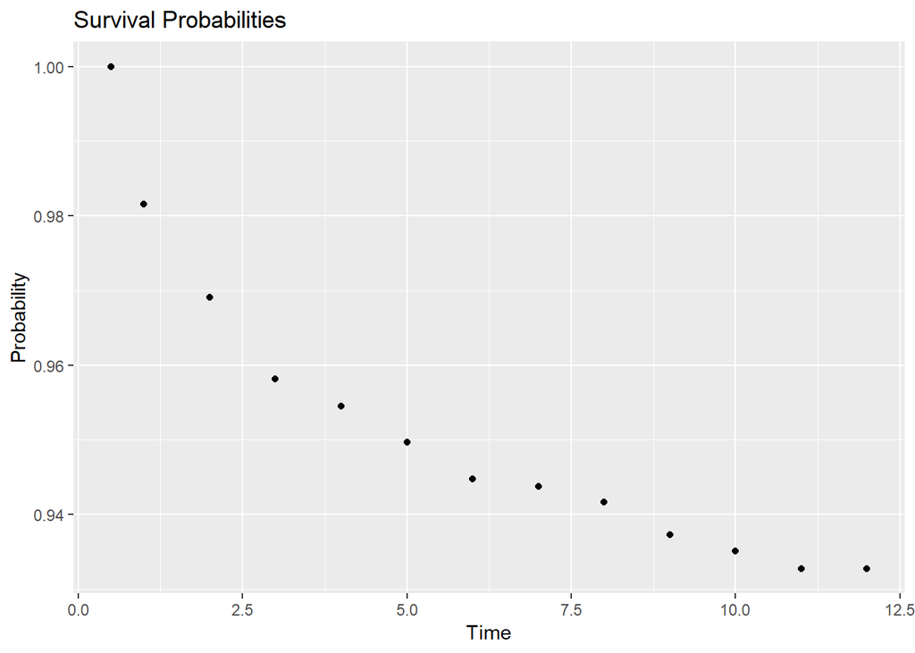

```r
data<-data.frame(Probability=case_surv$surv,Time=case_surv$time)
ggplot(data,aes(x=Time,y=Probability))+geom_point()+ggtitle("Survival Probabilities") #survive
```

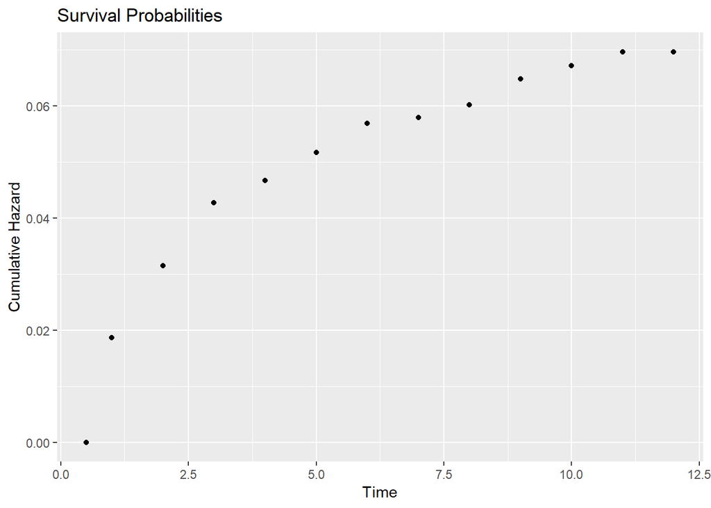

```r
data_1<-data.frame(Probability=case_surv$cumhaz,Time=case_surv$time)
ggplot(data_1,aes(x=Time,y=Probability)) + geom_point()+ ggtitle("Survival Probabilities") +
  xlab("Time") + ylab("Cumulative Hazard")
```